# Efecto de dieta antiviral y distintos niveles de EPA+DHA en el crecimiento de salmones infectados con PRV

Karen Vander Stelt Valderas

2022-05-24

## Descripción del problema a resolver

Piscine orthoreovirus (PRV) infecta al salmón del atlántico produciendo una inflamación sistémica conocida por sus siglas en inglés como HSMI. Se cree que el virus ingresa por vía intestinal para luego infectar glóbulos rojos produciendo un alto nivel del virus en sangre durante las primeras 5 semanas. En la etapa crónica de la enfermedad, PRV infecta cardiomiocitos lo cual gatilla una potente respuesta inflamatoria mientras que en músculo se pueden observar focos de melanosis. Los ácidos grasos omega-3 EPA y DHA favorecen el bienestar del salmón. Niveles adecuados de ambos favorecen la adaptación del pez de agua dulce a agua salada, tienen un efecto positivo en la pigmentación del salmón reduciendo los spots de melanina, ayudan a mantener la fluidez e integridad de las membranas celulares y contribuyen en la respuesta inmune debido a su fuerte efecto antiinflamatorio.

## Descripción de las variables de estudio, los factores que se desean analizar y el número total de observaciones.

El objetivo de este trabajo es determinar el efecto de dietas con distintos niveles de EPA+DHA en el peso y longitud de salmones infectados con PRV en 3 tiempos distintos, previo a la inoculación con PRV (Pre), 21 días después de la infección (Infcheck) y al día 203, final del ensayo (Final). Las cuatro dietas corresponden a: PRV1 Level 4: 3,4% EPA-DHA PRV2 Level 3: 2,2% EPA-DHA PRV3 Level 2: 1% EPA-DHA PRV4 Level 1: ~0% EPA-DHA

```r
data_prv <- read_excel("dataprv.xlsx", sheet= 1, na= "NA")
data_prv$handling <- as.factor(data_prv$handling)
data_prv$fish <- as.factor(data_prv$fish)
data_prv$tank <- as.factor(data_prv$tank)
data_prv$diet <- as.factor(data_prv$diet)
table(data_prv$handling, data_prv$diet)
```

```
##
##                                        PRV 1 Level 4 PRV 2 Level 3
##   Final sampling                                  88            90
##   Infection check                                 30            30
##   Pre- PRV innoculation (2nd sampling)            15            15
##
##                                        PRV 3 Level 2 PRV 4 Level 1
##   Final sampling                                  90            90
##   Infection check                                 30            30
##   Pre- PRV innoculation (2nd sampling)            15            15
```

```r
pander(summary(data_prv), caption = "Tabla resumen data frame")
```

Tabla resumen data frame (continued below)

| handling | fish | tank | diet |
| --- | --- | --- | --- |
| Final sampling :358 | 1 : 36 | B202 : 45 | PRV 1 Level 4:133 |
| Infection check :120 | 2 : 36 | B203 : 45 | PRV 2 Level 3:135 |
| Pre- PRV innoculation (2nd sampling): 60 | 3 : 36 | B204 : 45 | PRV 3 Level 2:135 |
| NA | 4 : 36 | B205 : 45 | PRV 4 Level 1:135 |
| NA | 5 : 36 | B206 : 45 | NA |
| NA | 6 : 24 | B207 : 45 | NA |
| NA | (Other):334 | (Other):268 | NA |

| weight_g | lenght_cm |
| --- | --- |
| Min. : 306.5 | Min. :29.50 |
| 1st Qu.: 570.6 | 1st Qu.:35.40 |
| Median : 729.8 | Median :38.50 |
| Mean : 723.6 | Mean :37.87 |
| 3rd Qu.: 859.0 | 3rd Qu.:40.40 |
| Max. :1331.8 | Max. :46.50 |
| NA | NA |

De acuerdo a la tabla resumen, este diseño experimental proporcionó datos que no están balanceados. En el muestreo previo a la infección se recogieron 60 datos de peso y 60 de longitud, los cuales corresponden a 15 individuos por dieta. En el segundo muestreo esta cantidad se duplicó, se obtuvieron 30 datos de peso y 30 de longitud por cada dieta, 120 en total para cada variable. Mientras que al final del ensayo se recopiló la data de todos los peces, cuyo número asciende a 358 datos en total, ~90 para cada dieta. En definitiva, a pesar de que dentro de un mismo muestreo la cantidad de datos es equitativa entre los grupos experimentales, lo ideal es que los muestreos contemplen el mismo número de muestras a analizar, de esta forma nos aseguramos de realizar un análisis estadístico lo más riguroso posible.

```r
data_prv <- data_prv %>%
     mutate(handling = recode(handling, 'Pre- PRV innoculation (2nd sampling)' = "Pre",
         'Infection check' = "Infcheck",
         'Final sampling' = "Final"))
```

### **Distribución de los datos**

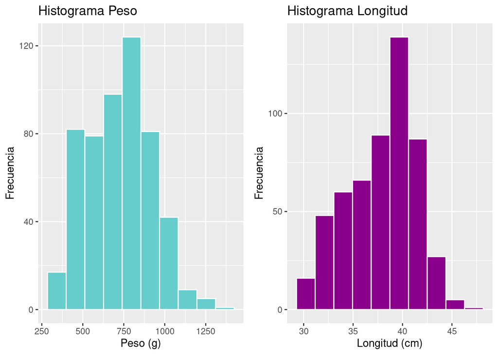

```r
hist_peso <- ggplot(data_prv, aes(weight_g)) + geom_histogram(bins= 10, color= "white", fill= "#66CCCC") + labs(title="Histograma Peso", x= "Peso (g)", y="Frecuencia")

hist_long <- ggplot(data_prv, aes(lenght_cm)) + geom_histogram(bins= 10, color= "white", fill= "darkmagenta") + labs(title="Histograma Longitud", x= "Longitud (cm)", y="Frecuencia")

grid.arrange(hist_peso, hist_long, ncol=2)
```

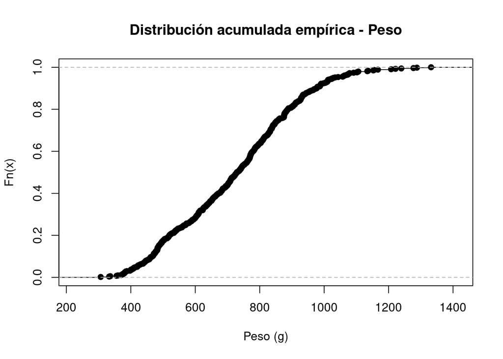

```r
plot(ecdf(data_prv$weight_g), main= "Distribución acumulada empírica - Peso", xlab= "Peso (g)")
```

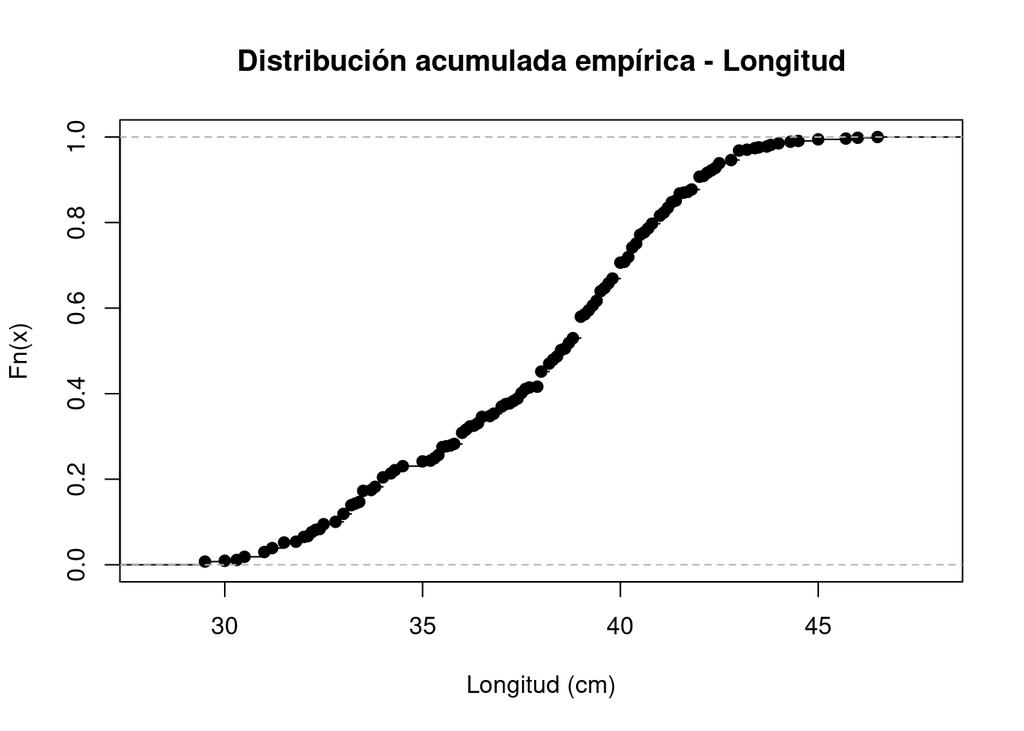

```r
plot(ecdf(data_prv$lenght_cm), main= "Distribución acumulada empírica - Longitud", xlab= "Longitud (cm)")
```

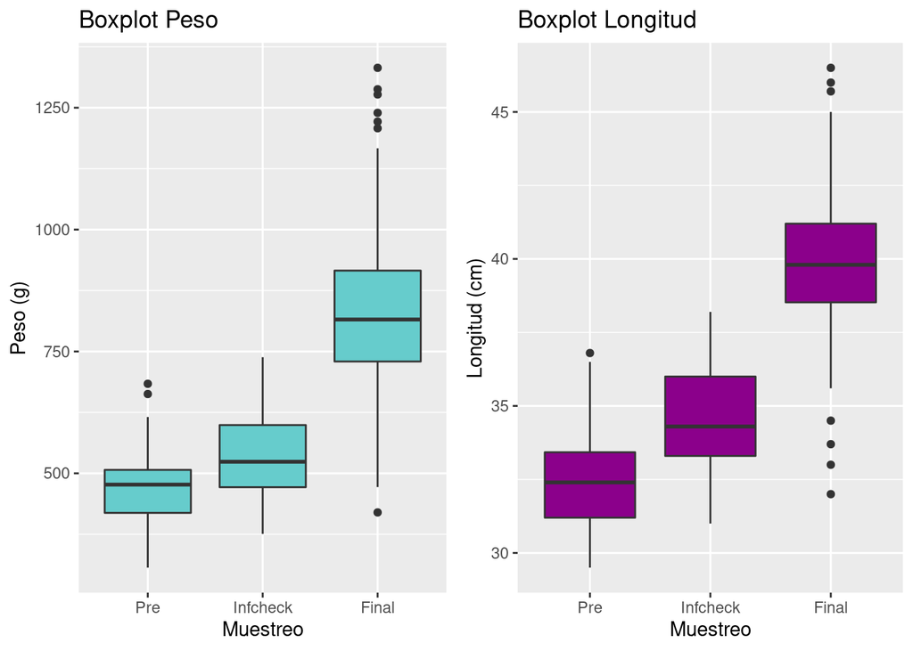

```r
data_prv$handling = with(data_prv, reorder(handling, weight_g, median))

box_peso <- ggplot(data_prv, aes(x=handling, y=weight_g)) + geom_boxplot(color="#333333", fill= "#66CCCC") + labs(title= "Boxplot Peso", x= "Muestreo", y= "Peso (g)")

box_long <- ggplot(data_prv, aes(x=handling, y=lenght_cm)) + geom_boxplot(color="#333333", fill= "darkmagenta") + labs(title= "Boxplot Longitud", x= "Muestreo", y= "Longitud (cm)")

grid.arrange(box_peso, box_long, ncol=2)
```

Al visualizar los histogramas se podría inferir que la distribución de los datos está directamente relacionada con la etapa del ensayo. Esto se confirma en los gráficos de boxplot.

Al inicio del ensayo (Pre) la media del peso y longitud es menor si se compara con los otros dos grupos. Los peces al final del ensayo alcanzan su tamaño máximo, la mayoría tiene un peso entre los 750 a 900 gramos mientras que la longitud promedio es cercana a los 40 centímetros. Pese a que la distribución es simétrica, se observan valores atípicos en el primer y tercer muestreo. Esto se debe tener en consideración mas adelante cuando se realicen los análisis de varianzas.

Las siguientes tablas resumen exponen los valores de la media, mediana, valores mínimos y máximos y la desviación estándar de los datos de peso y longitud de los tres muestreos realizados:

```r
Tabla_peso= data_prv %>% group_by(handling) %>% summarise(N=n(), Promedio= mean(weight_g), Mediana= median(weight_g), Valor_min= min(weight_g), Valor_max= max(weight_g), SD= sd(weight_g))
kable(Tabla_peso,caption ="Tabla resumen: Peso (g)") %>% kable_styling("bordered")
```

Tabla resumen: Peso (g)

| handling | N | Promedio | Mediana | Valor_min | Valor_max | SD |
| --- | --- | --- | --- | --- | --- | --- |
| Pre | 60 | 470.6033 | 476.85 | 306.5 | 683.7 | 81.60915 |
| Infcheck | 120 | 533.0250 | 523.75 | 375.7 | 738.2 | 82.06778 |
| Final | 358 | 829.8872 | 815.55 | 419.8 | 1331.8 | 139.58670 |

```r
Tabla_long= data_prv %>% group_by(handling) %>% summarise(N=n(), Promedio= mean(lenght_cm), Mediana= median(lenght_cm), Valor_min= min(lenght_cm), Valor_max= max(lenght_cm), SD= sd(lenght_cm))
kable(Tabla_long,caption ="Tabla resumen: Longitud (cm)") %>% kable_styling("bordered")
```

Tabla resumen: Longitud (cm)

| handling | N | Promedio | Mediana | Valor_min | Valor_max | SD |
| --- | --- | --- | --- | --- | --- | --- |
| Pre | 60 | 32.42833 | 32.4 | 29.5 | 36.8 | 1.715442 |
| Infcheck | 120 | 34.47167 | 34.3 | 31.0 | 38.2 | 1.598433 |
| Final | 358 | 39.91760 | 39.8 | 32.0 | 46.5 | 2.046120 |

### **Interacción**

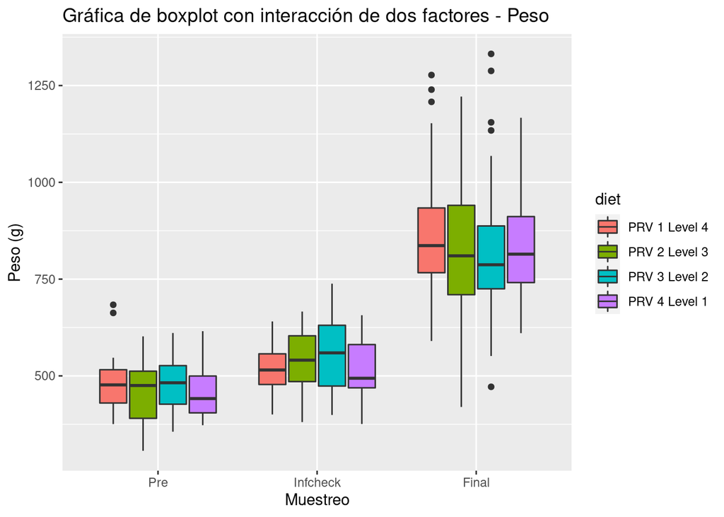

```r
ggplot(data_prv, aes(x=handling, y=weight_g, fill=diet)) +
    geom_boxplot()+
  labs(title= "Gráfica de boxplot con interacción de dos factores - Peso",
       x= "Muestreo", y="Peso (g)")
```

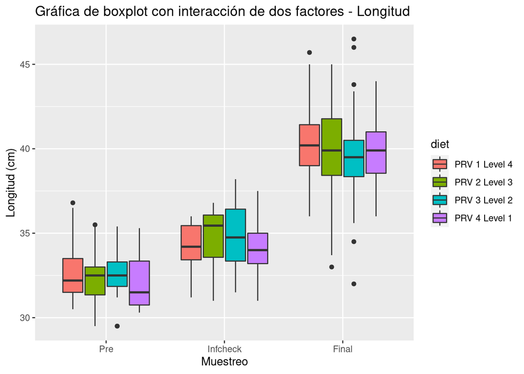

```r
ggplot(data_prv, aes(x=handling, y=lenght_cm, fill=diet)) +
    geom_boxplot()+
  labs(title= "Gráfica de boxplot con interacción de dos factores - Longitud", x= "Muestreo", y="Longitud (cm)")
```

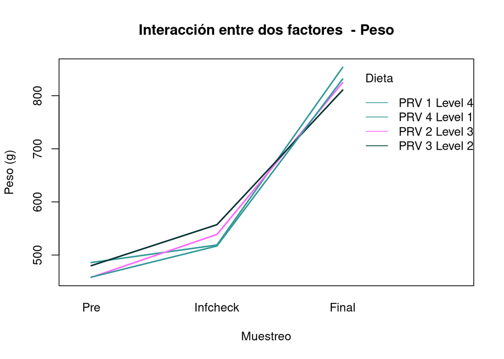

```r
interaction.plot(main= "Interacción entre dos factores  - Peso",
                 cex.main= 1.2,
                 x.factor = data_prv$handling, #x-axis variable
                 trace.factor = data_prv$diet, #variable for lines
                 response = data_prv$weight_g, #y-axis variable
                 fun = mean, #metric to plot
                 ylab = "Peso (g)",
                 xlab = "Muestreo",
                 cex.lab= 1,
                 col = c("#339999", "#FF66FF", "#003333"),
                 lty = 1, #line type
                 lwd = 2, #line width
                 trace.label = "Dieta")
```

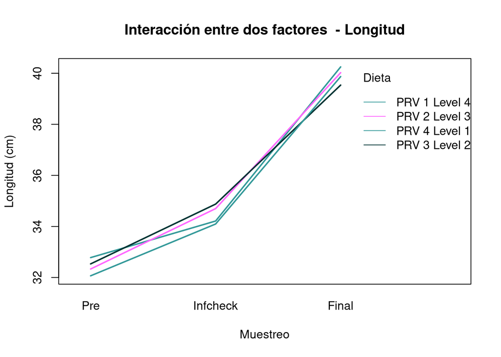

```r
interaction.plot(main= "Interacción entre dos factores  - Longitud",
                 cex.main= 1.2,
                 x.factor = data_prv$handling, #x-axis variable
                 trace.factor = data_prv$diet, #variable for lines
                 response = data_prv$lenght_cm, #y-axis variable
                 fun = mean, #metric to plot
                 ylab = "Longitud (cm)",
                 xlab = "Muestreo",
                 cex.lab= 1,
                 col = c("#339999", "#FF66FF", "#003333"),
                 lty = 1, #line type
                 lwd = 2, #line width
                 trace.label = "Dieta")
```

Al evaluar la interacción de los factores “Muestreo” y “Dieta” sobre las variables “Peso” y “Longitud” se puede concluir que los peces crecen a medida que transcurre el tiempo independiente del tipo de dieta que estén consumiendo.Es decir, la dieta no tiene efecto en la forma en que crecen los peces durante el ensayo. Por lo tanto, los factores no están interactuando entre sí.

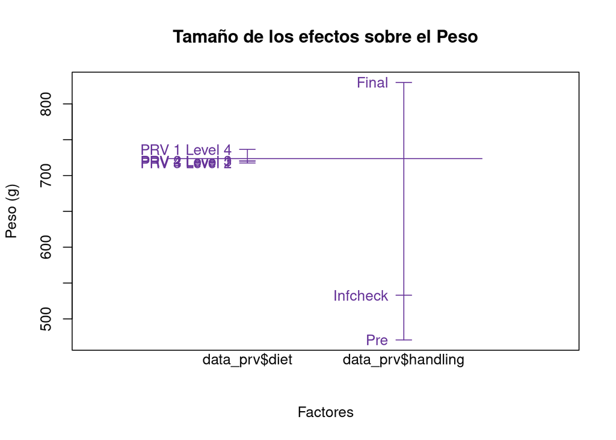

```r
#  Gráfica de tamaño de los efectos - MODELO DE INTERACCIÓN
# ¿Qué factor tiene una mayor influencia en la variable respuesta peso y en la variable longitud?

plot.design(data_prv$weight_g ~ data_prv$diet + data_prv$handling, main= "Tamaño de los efectos sobre el Peso",
            xlab = "Factores", ylab= "Peso (g)", col= "#663399")
```

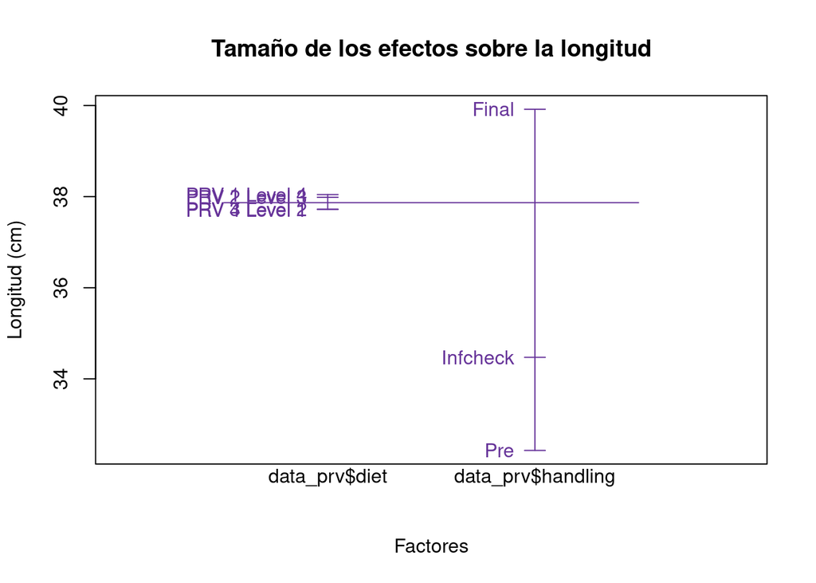

```r
plot.design(data_prv$lenght_cm ~ data_prv$diet + data_prv$handling, main= "Tamaño de los efectos sobre la longitud",
            xlab = "Factores", ylab= "Longitud (cm)", col= "#663399")
```

### **Conclusión**

El análisis exploratorio de los datos del ensayo denominado “Efecto de dieta antiviral y distintos niveles de EPA+DHA en el crecimiento de salmones infectados con PRV” demuestra que la concentración de los ácidos grasos omega 3 EPA y DHA en una dieta base antiviral no altera, afecta ni influye el crecimiento de los peces. Los datos, que corresponden a tres tiempos de muestreo: previo a la inoculación con el virus PRV, 21 días después de la infección y al final del ensayo, no son balanceados y además existen valores atípicos en el primer y tercer muestreo. Los gráficos de interacción y del tamaño de los efectos demostraron que los factores dieta y muestreo no interactúan entre sí y confirman que la dieta no influencia el crecimiento de los peces, estos crecen en función del tiempo.